# Mini Project 4

Author

Masaya Koga

**Task 1**

```r
# Load packages

library(httr2)
library(rvest)
library(dplyr)
library(tidyr)
library(lubridate)
library(stringr)
library(DT)

# Step 1: Send POST request to BLS

url <- "https://data.bls.gov/pdq/SurveyOutputServlet"

resp <- request(url) |>
  req_method("POST") |>
  req_body_form(
    request_action                   = "get_data",
    reformat                         = "true",
    from_results_page                = "true",
    from_year                        = "1979",
    to_year                          = "2025",
    `Go.x`                           = "2",
    `Go.y`                           = "11",
    initial_request                  = "false",
    data_tool                        = "surveymost",
    series_id                        = "CES0000000001",
    original_annualAveragesRequested = "false"
  ) |>
  req_headers(
    "User-Agent" = "Mozilla/5.0 (Windows NT 10.0; Win64; x64) AppleWebKit/537.36",
    "Referer" = "https://data.bls.gov/cgi-bin/surveymost"
  ) |>
  req_perform()

# Step 2: Extract table
html <- resp_body_html(resp)
data_table <- html |> html_element("table.regular-data")

if (!is.na(data_table)) {
  tbl <- data_table |> html_table(fill = TRUE)
} else {
  stop("No data table found — check request parameters.")
}

# Step 3: Clean + reshape into tidy format
colnames(tbl)[1] <- "Year"
month_cols <- setdiff(colnames(tbl), c("Year", "Annual", "Avg"))

df_long <- tbl |>
  filter(grepl("^(19|20)\\d{2}$", Year)) |>
  pivot_longer(cols = all_of(month_cols),
               names_to = "Month", values_to = "level") |>
  mutate(
    level_num   = as.numeric(str_remove_all(level, ",|\\s|\\*|\\(P\\)|\\(R\\)")),
    Month_abbr  = str_sub(Month, 1, 3),
    Month_int   = match(Month_abbr, month.abb),
    Year_int    = as.integer(Year),
    date        = make_date(Year_int, Month_int, 1)
  ) |>
  select(date, level = level_num) |>
  drop_na() |>
  arrange(date)

# Step 4: Datatable
datatable(df_long,
          options = list(pageLength = 25),
          caption = "Monthly CES Employment Level — Seasonally Adjusted (1979–2025)")
```

|  | date | level |
| --- | --- | --- |
| 1 | 1979-01-01 | 88808 |
| 2 | 1979-02-01 | 89055 |
| 3 | 1979-03-01 | 89479 |
| 4 | 1979-04-01 | 89417 |
| 5 | 1979-05-01 | 89789 |
| 6 | 1979-06-01 | 90108 |
| 7 | 1979-07-01 | 90217 |
| 8 | 1979-08-01 | 90300 |
| 9 | 1979-09-01 | 90327 |
| 10 | 1979-10-01 | 90481 |

[output cut: 551 more lines]

**Task 2**

```r
library(httr2)
library(rvest)
library(dplyr)
library(lubridate)
library(stringr)
library(purrr)
library(DT)

url <- "https://www.bls.gov/web/empsit/cesnaicsrev.htm"

page <- request(url) %>%
  req_method("GET") %>%
  req_headers(
    "User-Agent" = "Mozilla/5.0 (Windows NT 10.0; Win64; x64)",
    "Accept" = "text/html,application/xhtml+xml,application/xml;q=0.9,*/*;q=0.8"
  ) %>%
  req_perform() %>%
  resp_body_html()

# Extract all HTML tables
tables <- html_elements(page,"table")
dfs <- lapply(tables, \(x) suppressWarnings(
  tryCatch(html_table(x, header=FALSE), error=function(e) NULL)
))

# Identify valid CES year tables
valid_tables <- which(sapply(dfs, \(df)
  any(suppressWarnings(!is.na(as.numeric(df[[2]]))))
))

# Function to extract JAN–DEC rows
extract_block <- function(df){
  df <- df %>% slice(1:12)
  month <- match(substr(trimws(df[[1]]),1,3), month.abb)
  year  <- suppressWarnings(as.numeric(df[[2]]))

  tibble(
    date     = suppressWarnings(ymd(paste(year,month,1,sep="-"))),
    original = suppressWarnings(as.numeric(df[[3]])),
    final    = suppressWarnings(as.numeric(df[[5]])),
    revision = final-original
  )
}

# Build the CES revision dataset
ces_revisions <- map_dfr(valid_tables, \(i) extract_block(dfs[[i]])) %>%
  arrange(date) %>%
  filter(date >= ymd("1979-01-01"), date <= ymd("2025-06-01"))

# 5. Display as DATATABLE
datatable(
  ces_revisions,
  options = list(
    pageLength = 25
  )
)
```

|  | date | original | final | revision |
| --- | --- | --- | --- | --- |
| 1 | 1979-01-01 | 325 | 243 | -82 |
| 2 | 1979-02-01 | 301 | 294 | -7 |
| 3 | 1979-03-01 | 324 | 445 | 121 |
| 4 | 1979-04-01 | 72 | -15 | -87 |
| 5 | 1979-05-01 | 171 | 291 | 120 |
| 6 | 1979-06-01 | 97 | 225 | 128 |
| 7 | 1979-07-01 | 44 | 87 | 43 |
| 8 | 1979-08-01 | 2 | 49 | 47 |
| 9 | 1979-09-01 | 135 | 41 | -94 |
| 10 | 1980-01-01 | 305 | 411 | 106 |

[output cut: 410 more lines]

**Task 3**

**What and when were the largest revisions (positive and negative) in CES history?**

```r
library(dplyr)
library(lubridate)
library(ggplot2)
# Join levels + revisions
ces_full <- df_long %>%
  left_join(ces_revisions, by = "date") %>%
  filter(date >= ymd("1979-01-01"), date <= ymd("2025-06-01")) %>%
  arrange(date)

glimpse(ces_full)
```

```
Rows: 558
Columns: 5
$ date     <date> 1979-01-01, 1979-02-01, 1979-03-01, 1979-04-01, 1979-05-01, …
$ level    <dbl> 88808, 89055, 89479, 89417, 89789, 90108, 90217, 90300, 90327…
$ original <dbl> 325, 301, 324, 72, 171, 97, 44, 2, 135, NA, NA, NA, 305, 141,…
$ final    <dbl> 243, 294, 445, -15, 291, 225, 87, 49, 41, NA, NA, NA, 411, 19…
$ revision <dbl> -82, -7, 121, -87, 120, 128, 43, 47, -94, NA, NA, NA, 106, 52…
```

```r
#Largest positive revisions#

library(DT)
library(dplyr)

largest_positive <- ces_full %>%
  filter(!is.na(revision)) %>%
  slice_max(revision, n = 1, with_ties = FALSE) %>%
  mutate(type = "Largest Positive Revision") %>%
  relocate(type)   # moves label column to front

datatable(
  largest_positive,
  options = list(pageLength = 5
  )
)
```

|  | type | date | level | original | final | revision |
| --- | --- | --- | --- | --- | --- | --- |
| 1 | Largest Positive Revision | 1983-09-01 | 91247 | 733 | 1116 | 383 |

```r
largest_negative <- ces_full %>%
  filter(!is.na(revision)) %>%
  slice_min(revision, n = 1, with_ties = FALSE) %>%
  mutate(type = "Largest Negative Revision") %>%
  relocate(type)   # move classification column to the front
datatable(
  largest_negative,
  options = list(
    pageLength = 5
  )
)
```

|  | type | date | level | original | final | revision |
| --- | --- | --- | --- | --- | --- | --- |
| 1 | Largest Negative Revision | 2020-03-01 | 150895 | -701 | -1373 | -672 |

**What fraction of CES revisions are positive in each decade?**

```r
library(DT)

ces_decade <- ces_full %>%
  mutate(decade = (year(date) %/% 10) * 10)

frac_pos_by_decade <- ces_decade %>%
  group_by(decade) %>%
  summarise(
    number_of_months      = n(),
    percentage_positive   = mean(revision > 0, na.rm = TRUE) * 100,  # % of months positive
    .groups = "drop"
  )

datatable(
  frac_pos_by_decade,
  options=list(
    pageLength=10
  )
)
```

|  | decade | number_of_months | percentage_positive |
| --- | --- | --- | --- |
| 1 | 1970 | 12 | 55.55555555555556 |
| 2 | 1980 | 120 | 55.55555555555556 |
| 3 | 1990 | 120 | 74.44444444444444 |
| 4 | 2000 | 120 | 58.88888888888889 |
| 5 | 2010 | 120 | 61.11111111111111 |
| 6 | 2020 | 66 | 37.25490196078432 |

**What fraction of CES revisions are negative in each decade?**

```r
library(dplyr)
library(lubridate)
library(DT)

ces_decade <- ces_full %>%
  mutate(decade = (year(date) %/% 10) * 10)

frac_neg_by_decade <- ces_decade %>%
  group_by(decade) %>%
  summarise(
    number_of_months    = n(),
    percentage_negative = mean(revision < 0, na.rm = TRUE) * 100,
    .groups = "drop"
  )

datatable(
  frac_neg_by_decade,
  caption = "Fraction of Negative CES Revisions by Decade",
  options = list(pageLength = 10)
)
```

|  | decade | number_of_months | percentage_negative |
| --- | --- | --- | --- |
| 1 | 1970 | 12 | 44.44444444444444 |
| 2 | 1980 | 120 | 43.33333333333334 |
| 3 | 1990 | 120 | 25.55555555555555 |
| 4 | 2000 | 120 | 41.11111111111111 |
| 5 | 2010 | 120 | 38.88888888888889 |
| 6 | 2020 | 66 | 62.74509803921568 |

**Average Monthly Change in Employment**

```r
avg_monthly_change <- ces_full %>%
  mutate(change = level - lag(level)) %>%    # month-to-month growth
  summarise(
    avg_change = mean(change, na.rm = TRUE)
  )

avg_monthly_change
```

```
# A tibble: 1 × 1
  avg_change
       <dbl>
1       127.
```

**Total Net Employment Growth per Year (1979–2025)**

```r
library(dplyr)
library(lubridate)
library(DT)

employment_growth_by_year <- ces_full %>%
  mutate(year = year(date)) %>%
  group_by(year) %>%
  summarise(
    start_level = first(level),
    end_level   = last(level),
    net_growth  = end_level - start_level,   # growth within the year
    .groups = "drop"
  )

datatable(
  employment_growth_by_year,
  options = list(
    pageLength = 15
  ),
  caption = "Total Net Employment Growth by Year (1979–2025)"
)
```

|  | year | start_level | end_level | net_growth |
| --- | --- | --- | --- | --- |
| 1 | 1979 | 88808 | 90672 | 1864 |
| 2 | 1980 | 90800 | 90943 | 143 |
| 3 | 1981 | 91033 | 90895 | -138 |
| 4 | 1982 | 90565 | 88771 | -1794 |
| 5 | 1983 | 88990 | 92230 | 3240 |
| 6 | 1984 | 92673 | 96107 | 3434 |
| 7 | 1985 | 96372 | 98609 | 2237 |
| 8 | 1986 | 98732 | 100509 | 1777 |
| 9 | 1987 | 100678 | 103661 | 2983 |
| 10 | 1988 | 103753 | 106898 | 3145 |

[output cut: 37 more lines]

**Plot 1: CES Employment Level Over Time (Overall Trend)**

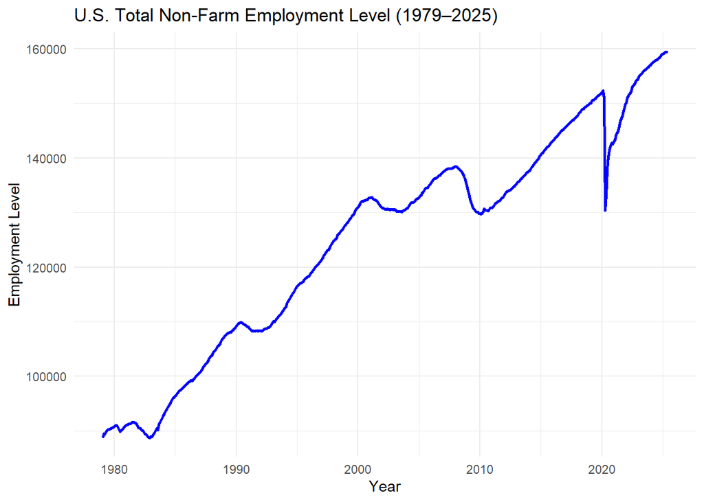

```r
library(ggplot2)

ggplot(ces_full, aes(x = date, y = level)) +
  geom_line(color = "blue", linewidth = 0.9) +
  labs(
    title = "U.S. Total Non-Farm Employment Level (1979–2025)",
    x = "Year",
    y = "Employment Level"
  ) +
  theme_minimal()
```

**Plot 2: Monthly CES Revisions Over Time (Accuracy Trend)**

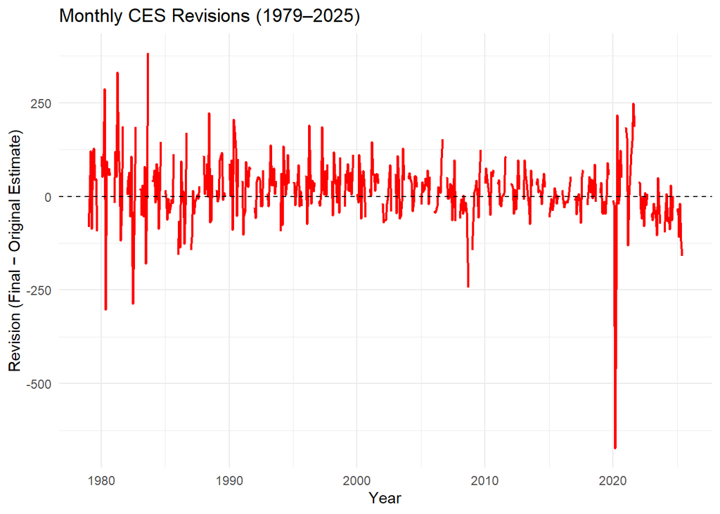

```r
ggplot(ces_full, aes(x = date, y = revision)) +
  geom_line(color = "red", linewidth = 0.8) +
  geom_hline(yintercept = 0, linetype = "dashed") +
  labs(
    title = "Monthly CES Revisions (1979–2025)",
    x = "Year",
    y = "Revision (Final − Original Estimate)"
  ) +
  theme_minimal()
```

**Plot 3: Distribution of CES Revisions (How often revisions are small/large)**

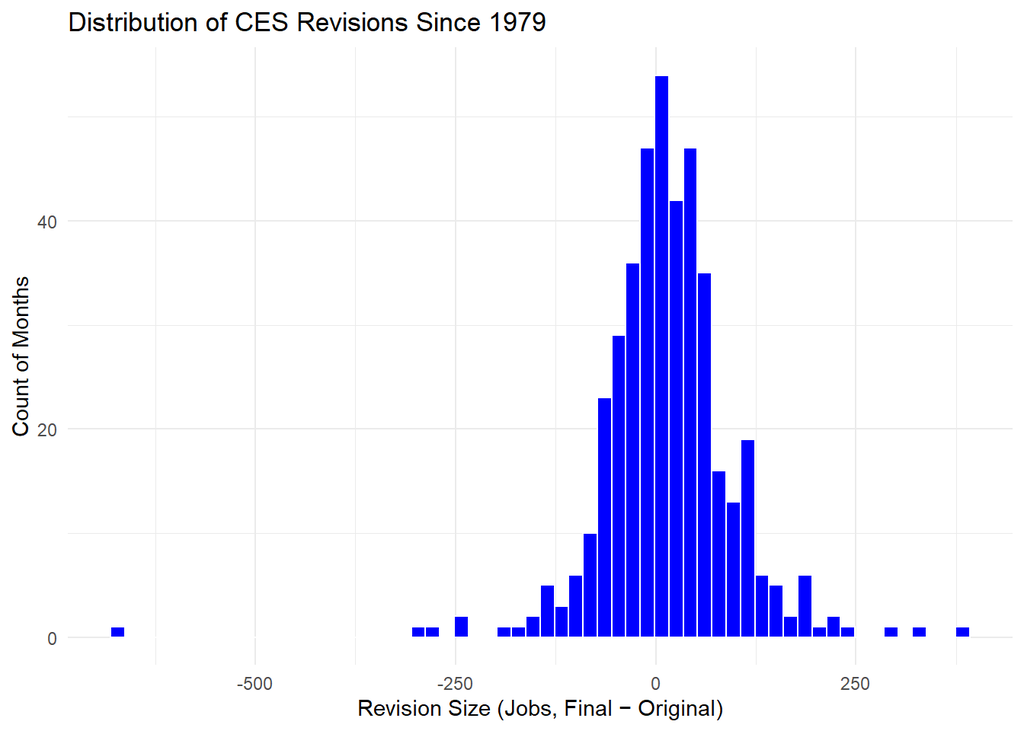

```r
ggplot(ces_full, aes(x = revision)) +
  geom_histogram(bins = 60, fill = "blue", color = "white") +
  labs(
    title = "Distribution of CES Revisions Since 1979",
    x = "Revision Size (Jobs, Final − Original)",
    y = "Count of Months"
  ) +
  theme_minimal()
```

**Plot 4: Original vs Final Employment Estimates Over Time**

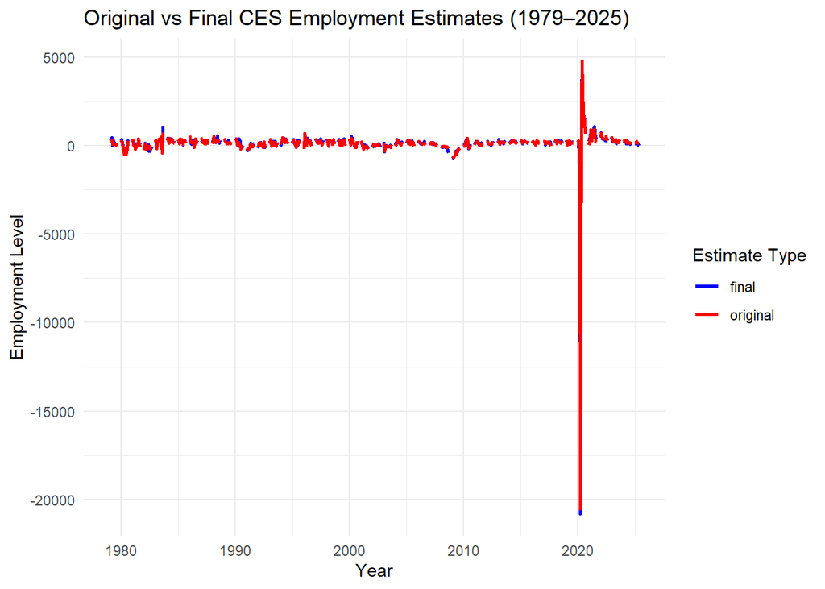

```r
library(tidyr)

ces_compare <- ces_full %>%
  select(date, original, final) %>%
  pivot_longer(cols = c(original, final),
               names_to = "estimate_type",
               values_to = "value")

ggplot(ces_compare, aes(x = date, y = value, color = estimate_type)) +
  geom_line(linewidth = 0.9) +
  labs(
    title = "Original vs Final CES Employment Estimates (1979–2025)",
    x = "Year",
    y = "Employment Level",
    color = "Estimate Type"
  ) +
  scale_color_manual(values = c("original" = "red", "final" = "blue")) +
  theme_minimal()
```

**Task 4**

**Question 1: Has the fraction of negative revisions increased post-2000?**

```r
library(dplyr)
library(lubridate)
library(infer)
ces_clean <- ces_full %>%
  mutate(
    year = year(date),
    revision = as.numeric(revision),
    change = level - lag(level),
    pct_revision = (revision / original) * 100
  ) %>%

  filter(!is.na(revision),
         !is.na(change),
         !is.na(pct_revision)) %>%

  mutate(
    revision_negative = factor(ifelse(revision < 0, "neg", "pos"),
                               levels = c("neg", "pos")),

    large_change = factor(ifelse(abs(change) > 150, "large", "small"),
                          levels = c("small", "large")),

    large_revision = factor(ifelse(abs(pct_revision) > 1, "large", "small"),
                            levels = c("small", "large")),

    post_2000 = factor(ifelse(year >= 2000, "post", "pre"),
                       levels = c("pre", "post")),

    post_2020 = factor(ifelse(year >= 2020, "post", "pre"),
                       levels = c("pre", "post"))
  )

t1 <- ces_clean %>%
  prop_test(
    response = revision_negative,
    explanatory = post_2000,
    order = c("post", "pre")
  )
t1
```

```
# A tibble: 1 × 6
  statistic chisq_df p_value alternative lower_ci upper_ci
      <dbl>    <dbl>   <dbl> <chr>          <dbl>    <dbl>
1      4.28        1  0.0386 two.sided    0.00617    0.203
```

Yes, per this test we saw that the fraction of negative CES revisions increased after 2000. A two-sample proportion test comparing the pre-2000 and post-2000 periods produced a statistically significant result where the p value was 0.0386.

```r
t2 <- ces_clean %>%
  prop_test(
    response = large_revision,
    explanatory = post_2020,
    order = c("post", "pre")
  )
t2
```

```
# A tibble: 1 × 6
  statistic chisq_df p_value alternative lower_ci upper_ci
      <dbl>    <dbl>   <dbl> <chr>          <dbl>    <dbl>
1      1.58        1   0.209 two.sided    -0.0374    0.117
```

**Question 3: Is the average revision significantly different from zero?**

```r
t3 <- ces_clean %>%
  t_test(response = revision, mu = 0)
t3
```

```
# A tibble: 1 × 7
  statistic  t_df  p_value alternative estimate lower_ci upper_ci
      <dbl> <dbl>    <dbl> <chr>          <dbl>    <dbl>    <dbl>
1      3.66   418 0.000287 two.sided       15.0     6.95     23.1
```

We conducted a one-sample t-test to determine whether the average CES revision differs from zero. The result was statistically significant as the p value was 0.000287. The estimated average revision is +15.0 jobs, with a 95% confidence interval of (6.95, 23.1).

**Question 4: Has the average revision increased post-2020?**

```r
t4 <- ces_clean %>%
  t_test(
    response = revision,
    explanatory = post_2020,
    order = c("post", "pre")
  )
t4
```

```
# A tibble: 1 × 7
  statistic  t_df p_value alternative estimate lower_ci upper_ci
      <dbl> <dbl>   <dbl> <chr>          <dbl>    <dbl>    <dbl>
1     -2.02  54.2  0.0482 two.sided      -38.8    -77.2   -0.326
```

We compared the mean CES revision before and after 2020 using a two-sample t-test. The result was statistically significant as the p value was 0.0482, indicating that the average revision differs between the two periods.

**Question 5: Are revisions larger when the underlying change in CES level is larger?**

```r
t5 <- ces_clean %>%
  t_test(
    response = revision,
    explanatory = large_change,
    order = c("large", "small")
  )
t5
```

```
# A tibble: 1 × 7
  statistic  t_df p_value alternative estimate lower_ci upper_ci
      <dbl> <dbl>   <dbl> <chr>          <dbl>    <dbl>    <dbl>
1    -0.448  376.   0.654 two.sided      -3.61    -19.5     12.2
```

We conducted a two-sample t-test comparing mean revisions between “large change” months and “normal change” months. The result was not statistically significant as the p value was 0.654.

**Task 5**

**Claim 1: “Jobs numbers were rigged under McEntarfer”**

```r
library(dplyr)
library(lubridate)
library(infer)
library(ggplot2)

stopifnot(exists("ces_clean"), exists("ces_full"))

# Claim 1: “Jobs numbers were rigged under McEntarfer” — compare revisions during 2023–mid-2025 vs earlier

ces_claim1 <- ces_clean %>%
  mutate(
    mc_period = if_else(
      date >= ymd("2023-01-01") & date <= ymd("2025-06-01"),
      "McEntarfer",
      "Other"
    )
  )

t_claim1_mean <- ces_claim1 %>%
  t_test(
    response = revision,
    explanatory = mc_period,
    order = c("McEntarfer", "Other")
  )

t_claim1_neg <- ces_claim1 %>%
  prop_test(
    response = revision_negative,
    explanatory = mc_period,
    order = c("McEntarfer", "Other")
  )

# Print Claim 1 test results
print("=== Claim 1 (mean revision) ===")
```

```
[1] "=== Claim 1 (mean revision) ==="
```

```r
print(t_claim1_mean)
```

```
# A tibble: 1 × 7
  statistic  t_df     p_value alternative estimate lower_ci upper_ci
      <dbl> <dbl>       <dbl> <chr>          <dbl>    <dbl>    <dbl>
1     -6.57  32.2 0.000000208 two.sided      -70.4    -92.3    -48.6
```

```r
print("=== Claim 1 (neg revision proportion) ===")
```

```
[1] "=== Claim 1 (neg revision proportion) ==="
```

```r
print(t_claim1_neg)
```

```
# A tibble: 1 × 6
  statistic chisq_df   p_value alternative lower_ci upper_ci
      <dbl>    <dbl>     <dbl> <chr>          <dbl>    <dbl>
1      17.7        1 0.0000257 two.sided      0.277    0.635
```

After a weak July 2025 jobs report and subsequent downward revisions to May and June’s reports, Donald Trump fired Bureau of Labor Statistics (BLS) Commissioner Erika McEntarfer, claiming that the jobs numbers were rigged to make republicans look bad (“Trump Fires BLS Commissioner”). However, as many economists and labor-statistics experts pointed out, revisions are routine.

**Claim 2: The Bureau of Labor Statistics (BLS) just revised down their jobs numbers from April 2024 to March 2025 by 911,000 jobs — the biggest revision on record and another blunder in the lengthy history of inaccuracies and incompetence at BLS.**

```r
library(dplyr)
library(lubridate)
library(infer)

# Define claimed period (latest 12 months)
ces_claim2 <- ces_clean %>%
  mutate(in_claim_period = factor(
    ifelse(date >= ymd("2024-04-01") & date <= ymd("2025-03-01"),
           "claim_period", "other_period"),
    levels = c("other_period", "claim_period")
  ))

# Two-sample t-test: Are claim-period revisions more negative?
t_claim2 <- ces_claim2 %>%
  t_test(
    revision ~ in_claim_period,
    alternative = "less",      # specifically testing more negative revisions
    order = c("claim_period", "other_period")
  )

t_claim2
```

```
# A tibble: 1 × 7
  statistic  t_df  p_value alternative estimate lower_ci upper_ci
      <dbl> <dbl>    <dbl> <chr>          <dbl>    <dbl>    <dbl>
1     -4.35  9.42 0.000836 less           -64.5     -Inf    -37.4
```

Visual evidence further contradicts the claim. Plot 2: Monthly CES Revisions Over Time shows that large downward revisions have occurred multiple times in past decades, often with much greater magnitude than the 2024–2025 episode. Likewise, Plot 4: Original vs Final Employment Estimates Over Time shows that the gap between initial and revised figures in 2024–2025 looks similar to earlier years, demonstrating that the recent adjustments do not stand out historically.

In conclusion, while it is true that recent revisions were more negative than the long-term norm, they were nowhere close to being the largest ever recorded. This claim exaggerates normal statistical corrections and falsely portrays them as unprecedented failure.

**Bibliography**

“BLS Revisions Show President Trump Was Right - Again.” The White House, The United States Government, 9 Sept. 2025, www.whitehouse.gov/articles/2025/09/bls-revisions-show-president-trump-was-right-again/.

Trump Fires BLS Commissioner, Claiming Weak Jobs Numbers Were ‘Rigged’ - the New York Times, www.nytimes.com/2025/08/01/business/economy/trump-bls-firing-jobs-report.html. Accessed 7 Dec. 2025.